# p8105_hw3_mnt2130

### Problem 2

The code below loads, reads, and cleans the accel dataset by creating useful variable names, creates a variable that tells us whether the day the data was collected was a weekend or weekday, and transposes the data from wide format to long format by collapsing the repeated columns of activity into one column and gives the activity count for each activity number in the following column.

```r
accel_tidied =
  read_csv("./data/accel_data.csv") %>%
  janitor::clean_names() %>%
  mutate(
    day_type = ifelse(day == "Saturday" | day == "Sunday", "Weekend", "Weekday"),
    day = factor(day, levels = c("Sunday", "Monday", "Tuesday", "Wednesday", "Thursday", "Friday", "Saturday"))
    ) %>%
  pivot_longer(
    cols = activity_1:activity_1440,
    names_to = "activity_number",
    values_to = "activity_count",
    names_prefix = "activity.",
  )
```

This dataset contains 50400 observations with 6 variables. The variables in this data set include week, day_id, day, day_type, activity_number, activity_count.

The code below shows how traditional accelerometer data is typically reported- total activity over the day by summing all the activity counts per day to create a daily total and creates a resulting table.

```r
  accel_daily_total = accel_tidied %>%
  group_by(week, day) %>%
  summarize(total_daily_activity = sum(activity_count)) %>%
  pivot_wider(
    names_from = day,
    values_from = total_daily_activity
  ) %>%
  knitr::kable(digits = 1)
accel_daily_total
```

| week | Sunday | Monday | Tuesday | Wednesday | Thursday | Friday | Saturday |
| --- | --- | --- | --- | --- | --- | --- | --- |
| 1 | 631105 | 78828.1 | 307094.2 | 340115 | 355923.6 | 480542.6 | 376254 |
| 2 | 422018 | 295431.0 | 423245.0 | 440962 | 474048.0 | 568839.0 | 607175 |
| 3 | 467052 | 685910.0 | 381507.0 | 468869 | 371230.0 | 467420.0 | 382928 |
| 4 | 260617 | 409450.0 | 319568.0 | 434460 | 340291.0 | 154049.0 | 1440 |
| 5 | 138421 | 389080.0 | 367824.0 | 445366 | 549658.0 | 620860.0 | 1440 |

This table shows the sum of activity count per each day of the week reported by the accelerometer. It appears that the study subject engaged in far less physical activity in Saturday of Week 4 and 5 in comparison to the other days. There is no apparent trend on the subject’s physical activity based on the table.

The codechunk belows creates a single panel plot showing the 24-hour activity time course for the subject each day and uses color to indicate each day of the week.

[output not shown]

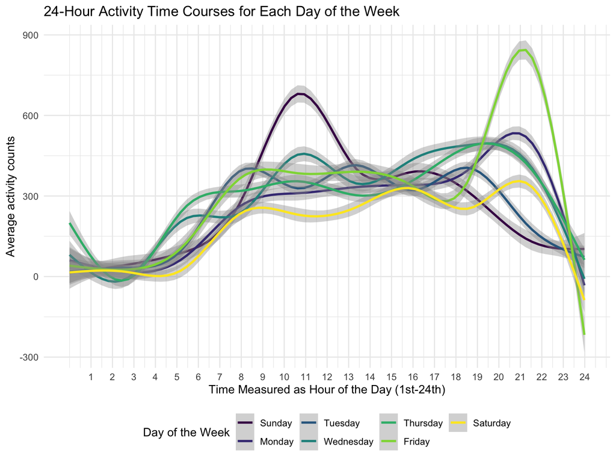

```r
accel_tidied %>%
  mutate(activity_number = as.numeric(activity_number)) %>%
  group_by(day, activity_number) %>%
  summarize(avg_value = mean(activity_count)) %>%
  ggplot(aes(x = activity_number, y = avg_value, color = day)) +
  geom_smooth() +
  scale_x_continuous(
    breaks = (1:24)*60 + 1,
    labels = c(1:24),
    name = "Time Measured as Hour of the Day (1st-24th)"
  ) +
  labs(
    title = "24-Hour Activity Time Courses for Each Day of the Week",
    x = "Hours (activity number)",
    y = "Average activity counts",
    color = "Day of the Week"
  )
```

The subject shows 2 peaks (maximum) in physical activity between the 10th and 11th hour on Sunday and on the 21st hour on Friday.

### Problem 3

```r
data("ny_noaa")
ny_noaa = ny_noaa %>%
  janitor::clean_names() %>%
  separate(date, c("year", "month", "day"), sep = "-") %>%
  mutate(tmax = as.double(tmax) / 10,
         tmin = as.double(tmin) / 10,
         prcp = prcp / 10,
         month = month.name[as.integer(month)],
         year = as.integer(year))
```

The ny_noaa datasetcontains 2595176 observations with 9 variables. The variables in this data set include id, year, month, day, prcp, snow, snwd, tmax, tmin. The data collected spans from 1981 until 2010. There are many observations with missing data, but that makes sense since each weather station only collects a subset of these variables.

```r
ny_noaa %>%
  group_by(snow) %>%
  count(snow)
```

```
## # A tibble: 282 × 2
## # Groups:   snow [282]
##     snow       n
##    <int>   <int>
##  1   -13       1
##  2     0 2008508
##  3     3    8790
##  4     5    9748
##  5     8    9962
##  6    10    5106
##  7    13   23095
##  8    15    3672
##  9    18    3226
## 10    20    4797
## # … with 272 more rows
```

For snowfall, the most commonly observed value is 0, which makes sense since it isn’t snowing in NY most days, especially during the spring, summer, and fall.

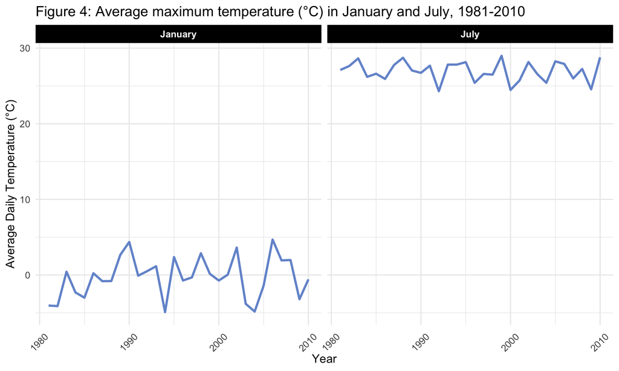

```r
ny_noaa %>%
  filter(month %in% c("January", "July")) %>%
  group_by(year, month) %>%
  summarize(avg_temp = mean(tmax, na.rm = TRUE)) %>%
  ggplot(aes(x = year, y = avg_temp)) +
    geom_line(color = "#7496D2", size = 1) +
  facet_grid(~ month,
             scales = "free") +
  labs(title = "Figure 4: Average maximum temperature (°C) in January and July, 1981-2010",
       x = "Year",
       y = "Average Daily Temperature (°C)") +
  theme(axis.text.x = element_text(angle = 45,
                                   vjust = 0.4),
        strip.background = element_rect(fill = "black"),
        strip.text = element_text(color = "white",
                                  face = "bold"))
```

This code makes a two panel plot that shows the max temperature vs the minimum temperature recorded for the full dataset. A scatterplot is not the best option since there are too many observations in the dataset, so we create a hexagon density plot. It also creates a a plot showing the distribution of snowfall values greater than 0 and less than 100 separately by year.

```r
temp_hex = ny_noaa %>%
  filter(!is.na(tmin),
         !is.na(tmax)) %>%
  ggplot(aes(x = tmin, y = tmax)) +
    geom_hex() +
    viridis::scale_fill_viridis(name = "",
                                option = "plasma") +
    theme(legend.position = "bottom",
          legend.key.height = unit(0.1, "in"),
          legend.key.width = unit(0.5, "in"),
          plot.title = element_text(size = 7)) +
    labs(title = "Hexagon density plot of daily minimum and maximum temperature (°C)",
         x = "Minimum Temperature (°C)",
         y = "Maximum Temperature (°C)") +
    scale_y_continuous(position = "left")
    theme(axis.text.x = element_text(angle = 45,
                                   vjust = 0.4),
        strip.background = element_rect(fill = "black"),
        strip.text = element_text(color = "white",
                                  face = "bold"))
```

[output not shown]

[figure not shown]

```r
snow_density = ny_noaa %>%
  filter(snow > 0 & snow < 100) %>%
  mutate(year = as.factor(year)) %>%
  mutate(year_cat = fct_collapse(year,
                                 "1981-85" = c("1981", "1982", "1983", "1984", "1985"),
                                 "1986-90" = c("1986", "1987", "1988", "1989", "1990"),
                                 "1991-95" = c("1991", "1992", "1993", "1994", "1995"),
                                 "1996-00" = c("1996", "1997", "1998", "1999", "2000"),
                                 "2001-05" = c("2001", "2002", "2003", "2004", "2005"),
                                 "2006-10" = c("2006", "2007", "2008", "2009", "2010"))) %>%
  ggplot(aes(x = snow, fill = year_cat, color = year_cat)) +
  geom_density(alpha = 0.01) +
    viridis::scale_fill_viridis(name = "Years",
                                discrete = TRUE) +
    viridis::scale_color_viridis(name = "Years",
                                 discrete = TRUE,
                                 option = "viridis") +
    labs(title = "Density plot of snowfall (mm), 1981-2010",
         x = "Snowfall (mm)",
         y = "Density") +
    theme(legend.position = "bottom",
          legend.direction = "horizontal",
          legend.key.size = unit(0.1, "in"),
          legend.text = element_text(size = 6),
          plot.title = element_text(size = 7))
snow_temp_plot <- snow_density + temp_hex
wrap_elements(snow_temp_plot) + ggtitle("Figure 5: Density and hexagon plots")
```

The snowfall was collapsed into 5 year intervals. From this we see that an average of 25mm of snow occurs the most often through the years of 1981-2010.